# Demand Prediction For Bike Sharing Systems

## Project Description

## Introduction

- Bike Sharing Systems (BSS) is a very widely used method of transportation for many people worldwide.
- They have several advantages:
  - Non-polluting.
  - Circumvents traffic congestion.
  - Excellent for last-mile connections.
  - Have a convenient payment system.

[figure not shown]

[figure not shown]

[figure not shown]

## Motivation

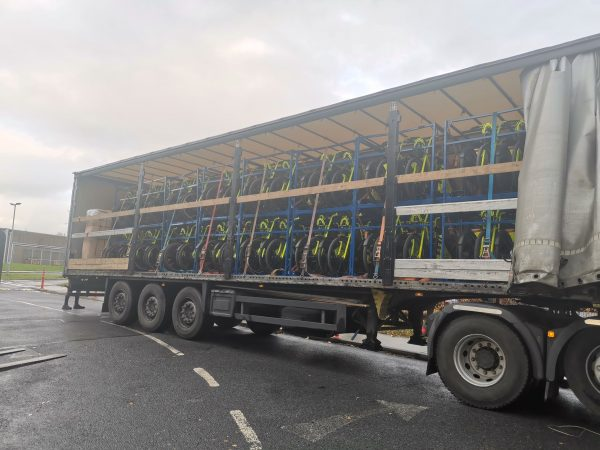

- BSSs use self-serve bikes locked to docking stations.
- Bikes are unlocked, used for a trip, then left at the closest station to their destination.
- Bikes need to be relocated from low demand to high demand stations.

## Problem Definition

- The relocation process could be costly and time consuming.
- Stations with high demand cannot be identified in advance.
- Stations with high return rate cannot be identified in advance.
- Relocation may not be important if return rate is high enough to fill the demand.

## Objectives

The objective is to create multivariate regression models capable of estimating the following

- **Demand prediction:** Number of bikes needed at each individual station.
- **Return prediction:** Number of bikes returned at each individual station.

[interactive chart not shown]

## Background

## Demand Prediction Models-Models

- **Univariate Time Series:**
  - Autoregressive moving Average (ARMA)
  - Autoregressive Integrated Moving Average (ARIMA)
- **Multivariate Time Series:**
  - Deep Learning with LSTM
  - Random Forest.
  - Boosting Algorithms.

## Demand Prediction Models-Features

- **Demographics:**
  - Wealth.
  - Average age.
- **Community**
- **Weather**
- **Sliding Window Statistics:**
  - Standard deviations.
  - Averages.

NB: Weather is especially important. BIXI BSS in Montreal is not operational in unfavorable weather, typically in mid-November to April.

## Dataset

## Lyft/Baywheels

The data was provided by Lyft, the owner of the BSS company Baywheels (formally GoBike) operating in San Francisco Bay Area.

- The data is available as far as 2017 before Lyft’s acquisition of GoBike.
- The data used however is limited to 2021 and 2022 because:
  - The disruption caused by the 2020 COVID pandemic.
  - Potential business growth gap between 2019 and 2021.

## Weather Data

- Weather data is very relevant in determining the demand.
- The weather data for San Francisco Bay Area is provided by Meteostat through a Python API.

[figure not shown]

## Dataset Description

### Size:

- **Original Number of Trips:** 4744199 trips .
- **Final Number of Trips:** 3855197 trips.
- **Number Of Stations**: 535
- **Period:** From January 2021 to December 2022

### Relevant Columns:

- Station Name (start/end)
- Time (start/end)
- Coordinates (start/end)
- Ride ID

## Cleaning Process

## Cleaning Process

- **Station Standardization:**
  - Stations in a particular street don’t always have the same coordinates.
  - Many stations don’t have a standardized name or ID, making them unidentifiable.
  - **Solution To Reduce Data Loss**:
    - Use a single coordinate for any identifiable stations.
    - Approximate the closest standard station to any trip.
    - If the closest station is less than 500 meters away, keep the trip, otherwise, drop.

## Cleaning Process

- **Same Station Trip:**
  - Several trips usually take place in several minutes, with the end station being the same as start stations.
  - This could be a result of users trying out the system or changed minds.
  - To prevent redundancy, any same station trip with duration less than 4 minutes will be removed.

## Cleaning Process

- **Clustering**:
  - Helps reduce weather data size by:
    - Approximating areas closest to each other.
    - Approximating the weather conditions for each cluster.
  - Separates the areas the BSS serves.

## Cleaning Process

[interactive chart not shown]

## Demand and Returns

**Definitions**

- Demand: Number of trips starting at a particular station.
- Returns: Number of trips ending at a particular station.
- “Returns” does not indicate actual number of bikes available, but it indicates how many bikes finished their trips there, which when compared with demand should provide a good idea about the available bikes.
- Therefore, demand will be the main focus, while returns will be taken as secondary.

## Demand

[interactive chart not shown]

## Demand and Returns

[interactive chart not shown]

## Demand Spread

[interactive chart not shown]

## Demand Spread

[interactive chart not shown]

## Results

## Testing Method

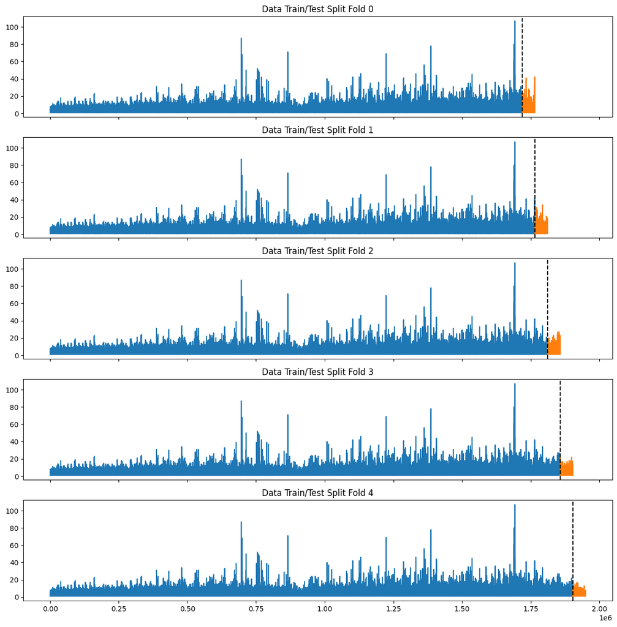

## Daily Demand Prediction

[interactive chart not shown]

## Hourly Demand Prediction

[interactive chart not shown]

## Daily Demand Prediction Example Station

[interactive chart not shown]

## Hourly Demand Prediction Example Station

[interactive chart not shown]

## RMSE

There are several criteria that can calculate the RMSE:

- Hourly Predictions: 1.4093 Bikes Error.
- Overall Daily Predictions: 4.4659 Bikes Daily
- Mean RMSE Hourly Per Station: 3.6386 Bikes hourly

## References

- Susan Shaheen, Stacey Guzman, and Hua Zhang. Bikesharing in europe, the americas, and asia. Transportation Research Record, pages 159–167, 1 2010.
- Andreas Nikiforiadis, Katerina Chrysostomou, and Georgia Aifadopoulou. Exploring travelers’ characteristics affecting their intention to shift to bike-sharing systems due to a sophisticated mobile app. Algorithms, 12:264, 12 2019.
- Jung-Hoon Cho, Young-Hyun Seo, and Dong-Kyu Kim. Efficiency comparison of public bike-sharing repositioning strategies based on predicted demand patterns. Transportation Research Record: Journal of the Trans-portation Research Board, 2675:104–118, 11 2021.
- Aliasghar Mehdizadeh Dastjerdi and Catherine Morency. Bike-sharing demand prediction at community level under covid-19 using deep learning. Sensors, 22:1060, 1 2022.
- Bike share in the san francisco bay area — bay wheels — lyft.
- Ahmed Ghanem, Hesham A. Rakha, and Leanna House. Modeling bike availability in a bike-sharing system using machine learning. pages 374–378. IEEE, 6 2017.
- Andreas Kaltenbrunner, Rodrigo Meza, Jens Grivolla, Joan Codina, and Rafael Banchs. Urban cycles and mobility patterns: Exploring and predicting trends in a bicycle-based public transport system. Pervasive and Mobile Computing, 6:455–466, 8 2010.
- Alvaro Lozano, Juan De Paz, Gabriel Villarrubia Gonz ́alez, Daniel Iglesia, and Javier Bajo. Multi-agent system for demand prediction and trip visualization in bike sharing systems. Applied Sciences, 8:67, 1 2018.
- R. Alexander Rixey. Station-level forecasting of bikesharing ridership. Transportation Research Record: Journal of the Transportation Research Board, 2387:46–55, 1 2013.
- Young-Hyun Seo, Sangwon Yoon, Dong-Kyu Kim, Seung-Young Kho, and Jaemin Hwang. Predicting demand for a bike-sharing system with station activity based on random forest. Proceedings of the Institution of Civil Engineers - Municipal Engineer, 174:97–107, 6 2021